# Aula Introdução ao Software R

# 17 Ferramentas para tratamento de dados

Parte significante do trabalho de análise de dados envolve trabalhar bases brutas e transformá-las em formatos mais interessantes. O R já vem com ferramentas para isso, mas elas não são tão eficientes quanto as disponibilizadas no pacote `dplyr`. A ideia do `dplyr` é oferecer uma *gramática dos dados*, uma maneira concisa e clara de manipulá-los.

`flights` vai carregar a base com os vôos:

```r
library(nycflights13)
library(tidyverse)

flights
```

```
# # A tibble: 336,776 × 19
#     year month   day dep_time sched_de…¹ dep_d…² arr_t…³ sched…⁴ arr_d…⁵ carrier
#    <int> <int> <int>    <int>      <int>   <dbl>   <int>   <int>   <dbl> <chr>
#  1  2013     1     1      517        515       2     830     819      11 UA
#  2  2013     1     1      533        529       4     850     830      20 UA
#  3  2013     1     1      542        540       2     923     850      33 AA
#  4  2013     1     1      544        545      -1    1004    1022     -18 B6
#  5  2013     1     1      554        600      -6     812     837     -25 DL
#  6  2013     1     1      554        558      -4     740     728      12 UA
#  7  2013     1     1      555        600      -5     913     854      19 B6
#  8  2013     1     1      557        600      -3     709     723     -14 EV
#  9  2013     1     1      557        600      -3     838     846      -8 B6
# 10  2013     1     1      558        600      -2     753     745       8 AA
# # … with 336,766 more rows, 9 more variables: flight <int>, tailnum <chr>,
# #   origin <chr>, dest <chr>, air_time <dbl>, distance <dbl>, hour <dbl>,
# #   minute <dbl>, time_hour <dttm>, and abbreviated variable names
# #   ¹sched_dep_time, ²dep_delay, ³arr_time, ⁴sched_arr_time, ⁵arr_delay
```

`filter()` te permite selecionar subconjuntos dos seus dados baseado em seus valores. O primeiro argumento é *sempre* um objeto `data.frame`, os subsequentes são argumentos lógicos que selecionem o que você quer:

```r
filter(flights, month == 1, day == 1)
```

```
# # A tibble: 842 × 19
#     year month   day dep_time sched_de…¹ dep_d…² arr_t…³ sched…⁴ arr_d…⁵ carrier
#    <int> <int> <int>    <int>      <int>   <dbl>   <int>   <int>   <dbl> <chr>
#  1  2013     1     1      517        515       2     830     819      11 UA
#  2  2013     1     1      533        529       4     850     830      20 UA
#  3  2013     1     1      542        540       2     923     850      33 AA
#  4  2013     1     1      544        545      -1    1004    1022     -18 B6
#  5  2013     1     1      554        600      -6     812     837     -25 DL
#  6  2013     1     1      554        558      -4     740     728      12 UA
#  7  2013     1     1      555        600      -5     913     854      19 B6
#  8  2013     1     1      557        600      -3     709     723     -14 EV
#  9  2013     1     1      557        600      -3     838     846      -8 B6
# 10  2013     1     1      558        600      -2     753     745       8 AA
# # … with 832 more rows, 9 more variables: flight <int>, tailnum <chr>,
# #   origin <chr>, dest <chr>, air_time <dbl>, distance <dbl>, hour <dbl>,
# #   minute <dbl>, time_hour <dttm>, and abbreviated variable names
# #   ¹sched_dep_time, ²dep_delay, ³arr_time, ⁴sched_arr_time, ⁵arr_delay
```

```r
# Para armazena-lo
dados.filtrados <- filter(flights, month == 1, day == 1)

# Uso do "ou" "|"
filter(flights, month == 11 | month == 12)
```

```
# # A tibble: 55,403 × 19
#     year month   day dep_time sched_de…¹ dep_d…² arr_t…³ sched…⁴ arr_d…⁵ carrier
#    <int> <int> <int>    <int>      <int>   <dbl>   <int>   <int>   <dbl> <chr>
#  1  2013    11     1        5       2359       6     352     345       7 B6
#  2  2013    11     1       35       2250     105     123    2356      87 B6
#  3  2013    11     1      455        500      -5     641     651     -10 US
#  4  2013    11     1      539        545      -6     856     827      29 UA
#  5  2013    11     1      542        545      -3     831     855     -24 AA
#  6  2013    11     1      549        600     -11     912     923     -11 UA
#  7  2013    11     1      550        600     -10     705     659       6 US
#  8  2013    11     1      554        600      -6     659     701      -2 US
#  9  2013    11     1      554        600      -6     826     827      -1 DL
# 10  2013    11     1      554        600      -6     749     751      -2 DL
# # … with 55,393 more rows, 9 more variables: flight <int>, tailnum <chr>,
# #   origin <chr>, dest <chr>, air_time <dbl>, distance <dbl>, hour <dbl>,
# #   minute <dbl>, time_hour <dttm>, and abbreviated variable names
# #   ¹sched_dep_time, ²dep_delay, ³arr_time, ⁴sched_arr_time, ⁵arr_delay
```

```r
#Outra possibilidade, armazenando
nov_dec <- filter(flights, month %in% c(11, 12))
```

`arrange()` funciona de maneira similar, mas ao invés de escolher pedaços dos dados, altera sua ordem. Alimentamos sempre um objeto `data.frame` e depois dizemos - em ordem - quais variáveis devem ser usadas para ordenação:

```r
arrange(flights, year, month, day)
```

```
# # A tibble: 336,776 × 19
#     year month   day dep_time sched_de…¹ dep_d…² arr_t…³ sched…⁴ arr_d…⁵ carrier
#    <int> <int> <int>    <int>      <int>   <dbl>   <int>   <int>   <dbl> <chr>
#  1  2013     1     1      517        515       2     830     819      11 UA
#  2  2013     1     1      533        529       4     850     830      20 UA
#  3  2013     1     1      542        540       2     923     850      33 AA
#  4  2013     1     1      544        545      -1    1004    1022     -18 B6
#  5  2013     1     1      554        600      -6     812     837     -25 DL
#  6  2013     1     1      554        558      -4     740     728      12 UA
#  7  2013     1     1      555        600      -5     913     854      19 B6
#  8  2013     1     1      557        600      -3     709     723     -14 EV
#  9  2013     1     1      557        600      -3     838     846      -8 B6
# 10  2013     1     1      558        600      -2     753     745       8 AA
# # … with 336,766 more rows, 9 more variables: flight <int>, tailnum <chr>,
# #   origin <chr>, dest <chr>, air_time <dbl>, distance <dbl>, hour <dbl>,
# #   minute <dbl>, time_hour <dttm>, and abbreviated variable names
# #   ¹sched_dep_time, ²dep_delay, ³arr_time, ⁴sched_arr_time, ⁵arr_delay
```

É comum trabalhar com bases de dados que tenham centenas ou mesmo milhares de variáveis. Para isso pode-se usar `select()` e simplificar a tarefa.

```r
# selecionando colunas por nome
select(flights, year, month, day)
```

```
# # A tibble: 336,776 × 3
#     year month   day
#    <int> <int> <int>
#  1  2013     1     1
#  2  2013     1     1
#  3  2013     1     1
#  4  2013     1     1
#  5  2013     1     1
#  6  2013     1     1
#  7  2013     1     1
#  8  2013     1     1
#  9  2013     1     1
# 10  2013     1     1
# # … with 336,766 more rows
```

- Para renomear variáveis usa-se `rename()`

```r
rename(flights, tail_num = tailnum)
```

```
# # A tibble: 336,776 × 19
#     year month   day dep_time sched_de…¹ dep_d…² arr_t…³ sched…⁴ arr_d…⁵ carrier
#    <int> <int> <int>    <int>      <int>   <dbl>   <int>   <int>   <dbl> <chr>
#  1  2013     1     1      517        515       2     830     819      11 UA
#  2  2013     1     1      533        529       4     850     830      20 UA
#  3  2013     1     1      542        540       2     923     850      33 AA
#  4  2013     1     1      544        545      -1    1004    1022     -18 B6
#  5  2013     1     1      554        600      -6     812     837     -25 DL
#  6  2013     1     1      554        558      -4     740     728      12 UA
#  7  2013     1     1      555        600      -5     913     854      19 B6
#  8  2013     1     1      557        600      -3     709     723     -14 EV
#  9  2013     1     1      557        600      -3     838     846      -8 B6
# 10  2013     1     1      558        600      -2     753     745       8 AA
# # … with 336,766 more rows, 9 more variables: flight <int>, tail_num <chr>,
# #   origin <chr>, dest <chr>, air_time <dbl>, distance <dbl>, hour <dbl>,
# #   minute <dbl>, time_hour <dttm>, and abbreviated variable names
# #   ¹sched_dep_time, ²dep_delay, ³arr_time, ⁴sched_arr_time, ⁵arr_delay
```

É comum precisar *criar* variáveis e isso pode ser feito com `mutate()`, que sempre irá adicionar a variável que especificarmos ao final do `data.frame`. Vamos gerar um objeto desssa classe, menor, e depois introduzir duas variáveis, `gain` que será a diferença dos atrasos de partida e chegada e `speed`, a velocidade média do vôo.

```r
base <- select(flights,
 year:day,
 ends_with("delay"),
 distance,
 air_time)
mutate(base,
 gain = arr_delay - dep_delay,
 speed = distance / air_time * 60)
```

```
# # A tibble: 336,776 × 9
#     year month   day dep_delay arr_delay distance air_time  gain speed
#    <int> <int> <int>     <dbl>     <dbl>    <dbl>    <dbl> <dbl> <dbl>
#  1  2013     1     1         2        11     1400      227     9  370.
#  2  2013     1     1         4        20     1416      227    16  374.
#  3  2013     1     1         2        33     1089      160    31  408.
#  4  2013     1     1        -1       -18     1576      183   -17  517.
#  5  2013     1     1        -6       -25      762      116   -19  394.
#  6  2013     1     1        -4        12      719      150    16  288.
#  7  2013     1     1        -5        19     1065      158    24  404.
#  8  2013     1     1        -3       -14      229       53   -11  259.
#  9  2013     1     1        -3        -8      944      140    -5  405.
# 10  2013     1     1        -2         8      733      138    10  319.
# # … with 336,766 more rows
```

Se você quer *somente* as variáveis geradas, então use `transmute()`:

```r
transmute(flights,
 gain = arr_delay - dep_delay,
 hours = air_time / 60)
```

```
# # A tibble: 336,776 × 2
#     gain hours
#    <dbl> <dbl>
#  1     9 3.78
#  2    16 3.78
#  3    31 2.67
#  4   -17 3.05
#  5   -19 1.93
#  6    16 2.5
#  7    24 2.63
#  8   -11 0.883
#  9    -5 2.33
# 10    10 2.3
# # … with 336,766 more rows
```

# 18 Operador Pipe

`Pipes` (ou tubos) são uma ferramenta poderosa para expressar claramente uma sequência de várias operações. `Pipes`, *%>%*, são carregados através do pacote *magrittr*. O objetivo do `pipe` é ajudá-lo a escrever código de uma maneira que seja mais fácil de ler e entender.

```r
library(tidyverse)
library(magrittr)

diamonds <- ggplot2::diamonds
diamonds2 = mutate(diamonds, price_per_carat = price / carat)

summary(diamonds2$price_per_carat)
```

```
#    Min. 1st Qu.  Median    Mean 3rd Qu.    Max.
#    1051    2478    3495    4008    4950   17829
```

```r
# E agora usando o `pipe`:

diamonds3 <- diamonds %>%
  dplyr::mutate(price_per_carat = price / carat)

summary(diamonds3$price_per_carat)
```

```
#    Min. 1st Qu.  Median    Mean 3rd Qu.    Max.
#    1051    2478    3495    4008    4950   17829
```

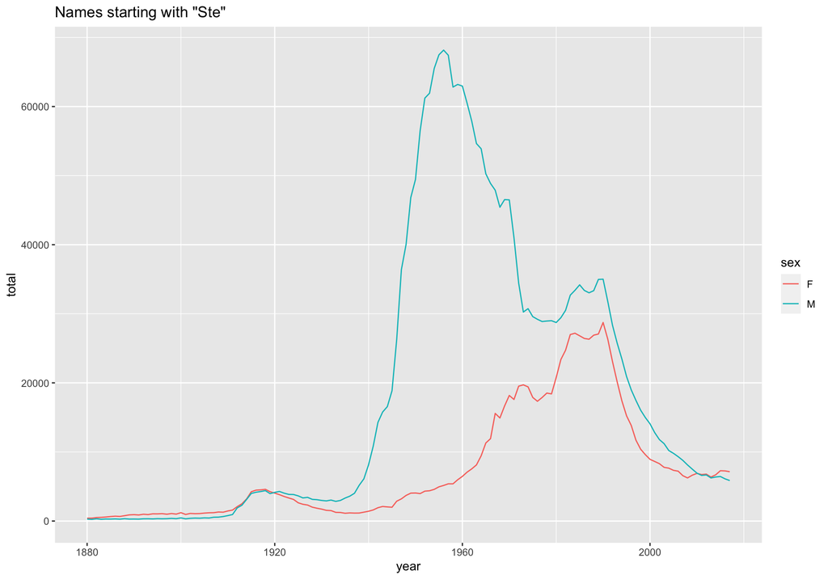

```r
library(babynames) # data package
library(dplyr)     # funções para manipular dados.
library(magrittr)  # para o pipe
library(ggplot2)   # para o gráfico

babynames %>%
    filter(name %>% substr(1, 3) %>% equals("Ste")) %>%
    group_by(year, sex) %>%
    summarize(total = sum(n)) %>%
    qplot(year, total, color = sex, data = ., geom = "line") %>%
    add(ggtitle('Names starting with "Ste"')) %>%
    print
```

A sequência de códigos contida no `pipe` pode ser descrita como uma espécie de receita:

1. pegue os dados do bebê e depois
2. filtre-o de modo que o nome da sub-string do caractere 1 a 3 seja igual a “Ste” e, em seguida,
3. agrupe-o por ano e sexo, depois
4. resuma-o calculando a soma total de cada grupo e, em seguida,
5. traçar os resultados, colorindo por sexo, depois
6. adicione um título e, em seguida,
7. imprima na tela.

O exemplo ilustra alguns recursos do `%>%`. Em primeiro lugar, as funções dplyr `filter`, `group_by` e `summarise`, todos tomam como primeiro argumento um objeto de dados e, por padrão, é onde o `%>%` o colocará no seu lado esquerdo.

Os dados de nomes de bebês são inseridos como primeiro argumento na chamada para `filter`. Quando a filtragem é concluída, o resultado é passado como o primeiro argumento para `group_by` e da mesma forma para `summarise`.

No entanto, nem sempre é uma sorte que uma função seja projetada para aceitar os dados (ou o que quer que você esteja transmitindo) como seu primeiro argumento (as funções dplyr são projetadas com `%>%` de operações em mente). É o caso de, por exemplo, qplot, mas observe os dados =. argumento. Isso indica a `%>%` para colocar o lado esquerdo lá, e não como o primeiro argumento. Essa é uma maneira simples e natural de acomodar a falta de consistência das assinaturas de funções e permite que o lado esquerdo vá para qualquer lugar da chamada no lado direito.

Além disso, `print` é usada sem parênteses; isso é para tornar o código ainda mais limpo quando apenas um lado esquerdo for necessário como entrada. Por fim, observe que `%>%` pode ser usado de forma aninhada (uma cadeia separada é encontrada na chamada de `filter`) e que o `magrittr` possui aliases para operadores comumente usados, como adicionar para + e igual a == usado acima. Isso torna as cadeias de `pipes` mais legíveis (não necessariamente menores).

## 18.1 Outros exemplos com Pipe

Imagine que estamos procurando uma relação entre algumas variáveis dos dados:

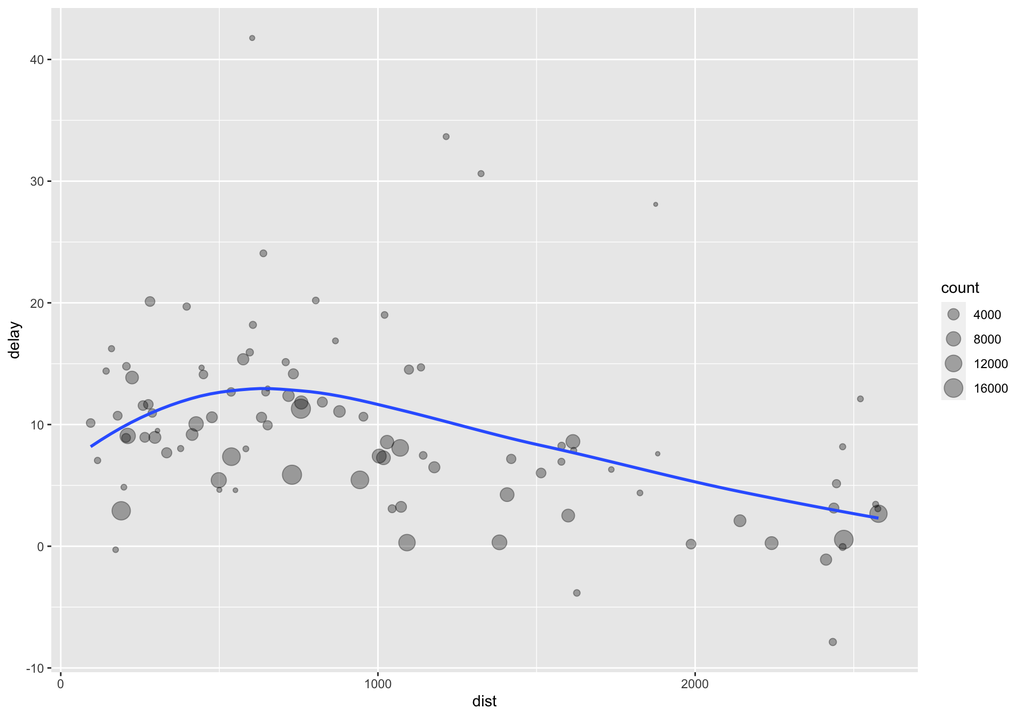

```r
por_distancia <- group_by(flights, dest)
atraso <- summarize(por_distancia,
 count = n(), dist = mean(distance, na.rm = TRUE),
 delay = mean(arr_delay, na.rm = TRUE))
delay <- filter(atraso, count > 20, dest != "HNL")

ggplot(data = delay, mapping = aes(x = dist, y = delay)) +
 geom_point(aes(size = count), alpha = 1/3) +
 geom_smooth(se = FALSE)
```

Foi feita uma sequência de passos grande e facilmente algo poderia ter saído errado. Além de que, qualquer alteração em uma linha de código provavelmente vai exigir que se altere em outras. Resolvemos isso com o operador `%>%`, o Pipe. Entenda ele como um cano, que “engata” funções.

```r
atrasos <- flights %>%
 group_by(dest) %>%
 summarize(count = n(), dist = mean(distance, na.rm = TRUE), delay = mean(arr_delay, na.rm = TRUE)) %>%
 filter(count > 20, dest != "HNL")
```

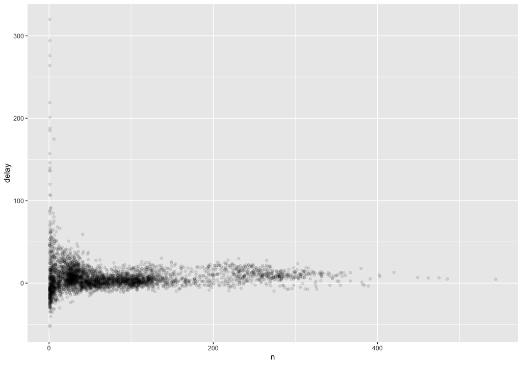

```r
nao_cancelados <- flights %>%
 filter(!is.na(dep_delay), !is.na(arr_delay))
atrasos <- nao_cancelados %>%
 group_by(tailnum) %>%
 summarize(delay = mean(arr_delay, na.rm = TRUE),
 n = n())
ggplot(data = atrasos, mapping = aes(x = n, y = delay)) +
 geom_point(alpha = 1/10)
```

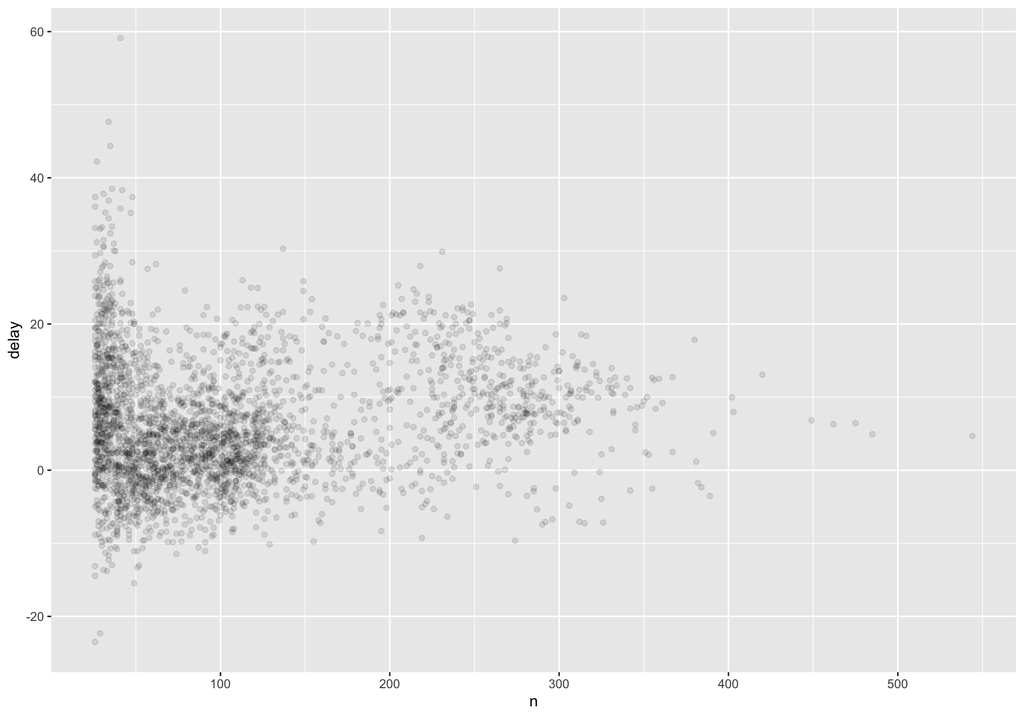

```r
atrasos %>%
 filter(n > 25) %>%
 ggplot(mapping = aes(x = n, y = delay)) +
 geom_point(alpha = 1/10)
```